# Кросс-категорийные продажи P&G в магазинах «Магнит Косметик».

В нашем распряжении два датасета. Датасет "customers" содержит в себе информацию о покупателях, зарегистрированных в системе "Магнит Косметик" через персональную карту. Каждому из этих покупателей приписан уникальный id в системе. У нас есть информация о возрастной группе, поле покупателя и дате регистрации в системе, канал попадания покупателя в систему "Магнит Косметик".

Второй датасет "purchases" представляет собой чеки из магазина "Магнит Косметик", в которых есть товар компании P&G. Приобретенная категория товара хранится в столбце "product". Есть информация о цене проданного товара, преобразованная в данные от -1 до 1, ценовой сегмент купленного товара (от "1" - Эконом, до "4" - Премиум), информация о других товарах в чеке (относящихся и не относящихся к P&G).

Необходимо:

1. Провести обработку исходных данных и исследовать датасет на наличие определенных последовательностей и трендов.
2. Составить матрицу кросс-продаж non-food категорий в «Магнит Косметик» и понять, как увеличить рост продаж товаров P&G.
3. Исходя из анализа данных и взаимосвязи товаров в матрице кросс-продаж, сделать выводы и дать рекомендации по повышению объема продаж с учетом выявленных закономерностей.

### 1. Выгрузка и первичная обработка данных

```python
# загрузка библиотек
import pandas as pd
pd.options.mode.chained_assignment = None
import warnings
warnings.simplefilter(action='ignore', category=FutureWarning)
import numpy as np
import datetime as dt
import matplotlib.pyplot as plt
%matplotlib inline
from matplotlib.ticker import PercentFormatter
from pandas.plotting import register_matplotlib_converters
import warnings
import scipy.stats as stats
import csv
import pandas as pd
import matplotlib.pyplot as plt
import seaborn as sns
import mlxtend.frequent_patterns
import mlxtend.preprocessing
```

```python
# загружаем данные из файла purchases - покупки
purchases = pd.read_csv('C:\\Users\\Пользователь\\Desktop\\it\\png_magnit_purchases.csv')
```

```python
# первые 5 строк данных "покупки"
purchases.head(5)
```

|  | purchase date | customer | product | other_product | p&g_product | cost_product | cost_p&g | product_segment | p&g_segment |
| --- | --- | --- | --- | --- | --- | --- | --- | --- | --- |
| 0 | 2021-12-05 | 46501ab5e1d554f1a40c | Бумажные салфетки | 1.0 | 0.0 | 0.719656 | NaN | 2.0 | NaN |
| 1 | 2021-11-29 | fe4b24b8d77d1ac3990f | Мыло кусковое | 5.0 | 0.0 | -0.612290 | NaN | 3.0 | NaN |
| 2 | 2021-01-26 | ed14e760a20f500bbbeb | Упаковка подарков | 1.0 | 0.0 | 0.034713 | NaN | 3.0 | NaN |
| 3 | 2021-12-02 | 06337c560d6052ab73e4 | Соли для душа | 1.0 | 0.0 | -0.468906 | NaN | 3.0 | NaN |
| 4 | 2021-03-03 | 92d6c8144600df232b8e | Маски для лица | 1.0 | 0.0 | 4.273955 | NaN | 3.0 | NaN |

Мы видим отсутствующие значения в первых пяти строках столбцов "cost_p&g" и "p&g_segment", так как в этих чеках значится только один купленный продукт P&G, отраженный в столбце "product". Информация о его стоимости предоставлена в столбцах "cost_product" (цена товара), "product_segment" (сегмент товара). Если бы в столбце "p&g_product" была бы отражена информация о еще одном купленном товаре P&G, данные в столбцах "cost_p&g" и "p&g_segment" могли бы быть заполнены.

```python
# убедимся в верности гипотезы выше: столбцы "p&g_segment" и "cost_p&g"
# содержат в себе информацию только тогда, когда "p&g_product" не равен нулю.
# purchases[(purchases['p&g_segment'].notna()) & (purchases['p&g_product']< 1)].head(10)
# в данных нет строк, которые одновременно были бы пустыми в "p&g_product" и содержали информацию в "p&g_segment"
# это же работает и в обратную сторону:
# purchases[(purchases['p&g_product'].notna()) & (purchases['p&g_segment']< 1)].head(10)
```

```python
#проверим, что отражает информация в данных о сегменте дополнительного купленного товара P&G ("p&g_segment"), если в чеке указано ("p&g_product"), что куплено несколько товаров P&G
# purchases[purchases['p&g_product'] > 1].head(10)
# столбец "p&g_segment" не оказался пустым, однако мы не можем знать наверняка, к какому из двух и более дополнительных купленных товаров в чеке ("p&g_product") относятся данные по сегменту ("p&g_segment")
```

```python
purchases.info()
```

```
<class 'pandas.core.frame.DataFrame'>
RangeIndex: 14441625 entries, 0 to 14441624
Data columns (total 9 columns):
 #   Column           Dtype
---  ------           -----
 0   purchase date    object
 1   customer         object
 2   product          object
 3   other_product    float64
 4   p&g_product      float64
 5   cost_product     float64
 6   cost_p&g         float64
 7   product_segment  float64
 8   p&g_segment      float64
dtypes: float64(6), object(3)
memory usage: 991.6+ MB
```

В данных "покупки" ("purchases") сохранено 14 млн 441 тыс. 625 строк с уникальными чеками.

```python
# можем убедиться, что товары из столбца ['product'] не разделены по сегментам
# purchases[(purchases['product'] == 'Бумажные салфетки')].sort_values(by = 'product_segment')
# purchases[(purchases['product'] == 'Мыло кусковое')].sort_values(by = 'product_segment')
```

```python
# узнаем, есть ли у нас в данных выбросы по типам данных: в данных не может быть куплены дробное число товаров, не может быть дробное число категории сегмента
# уникальные значения столбцов дадут нам представление о необходимости удалить данные
purchases['other_product'].unique()
```

```
array([ 1.,  5.,  0.,  3.,  4.,  2.,  9.,  8.,  6.,  7., 13., 10., 12.,
       14., 17., 11., 16., 19., 15., 18., 28., 20., 23., 21., 22., 25.,
       32., 24., 26., 30., 27., 31., 29., 37., 36., 34., 38.])
```

```python
purchases['p&g_product'].unique()
```

```
array([ 0.,  1.,  2.,  3.,  4.,  5.,  8.,  6.,  7., 11.])
```

```python
purchases['product_segment'].unique()
```

```
array([2.      , 3.      , 4.      ,      nan, 3.5     , 3.666666,
       3.833333, 3.75    , 1.      , 3.333333, 3.25    , 3.90909 ,
       3.8     , 3.6     , 3.4     , 3.714285, 3.571428, 3.888888,
       3.857142, 3.2     , 3.222222, 3.875   , 3.777777, 3.9     ,
       3.727272, 3.428571, 3.285714, 3.866666, 3.166666, 3.636363,
       3.7     , 3.625   , 3.705882, 3.142857, 3.916666, 3.444444,
       3.583333, 3.181818, 3.8125  ])
```

```python
# посчитаем, сколько у нас строк до удаления
purchases['product_segment'].count()
```

```
13173586
```

```python
# удалим из таблицы строки с дробными числами в столбце сегмента
allowedseg = [1,2,3,4, np.nan]
purchases = purchases.loc[purchases['product_segment'].isin(allowedseg)]
```

```python
# посчитаем, сколько у нас строк после удаления
purchases['product_segment'].count()
```

```
13154434
```

```python
print (f'Процент удаленных дробных данных: {1-(13154434/13173586):.2%}')
```

```
Процент удаленных дробных данных: 0.15%
```

```python
# проверка
purchases['product_segment'].unique()
```

```
array([ 2.,  3.,  4., nan,  1.])
```

```python
purchases['p&g_segment'].unique()
```

```
array([nan,  3.,  2.])
```

```python
# если отсутствующих данных немного в датасете, их можно безболезненно удалить
# посчитаем проценты nan в данных
print(f"Процент пропущенных значений в столбце 'product_segment': {purchases['product_segment'].isna().sum()/len(purchases['product_segment']):.1%}")
```

```
Процент пропущенных значений в столбце 'product_segment': 8.8%
```

```python
# удалим пропущенные значения в 'product_segment'
purchases = purchases.dropna(subset= ['product_segment']).reset_index()
```

```python
print(f"Процент пропущенных значений в столбце 'p&g_segment': {purchases['p&g_segment'].isna().sum()/len(purchases['product_segment']):.1%}")
```

```
Процент пропущенных значений в столбце 'p&g_segment': 99.2%
```

```python
#преобразуем где возможно данные в необходимые для вычислений и обработки формат int и datetime
purchases['other_product'] = purchases['other_product'].astype("int")
purchases['p&g_product'] = purchases['p&g_product'].astype("int")
purchases['purchase date'] = pd.to_datetime(purchases['purchase date'])
purchases['product_segment'] = purchases['product_segment'].astype("int")
```

```python
purchases.info()
```

```
<class 'pandas.core.frame.DataFrame'>
RangeIndex: 13154434 entries, 0 to 13154433
Data columns (total 10 columns):
 #   Column           Dtype
---  ------           -----
 0   index            int64
 1   purchase date    datetime64[ns]
 2   customer         object
 3   product          object
 4   other_product    int32
 5   p&g_product      int32
 6   cost_product     float64
 7   cost_p&g         float64
 8   product_segment  int32
 9   p&g_segment      float64
dtypes: datetime64[ns](1), float64(3), int32(3), int64(1), object(2)
memory usage: 853.1+ MB
```

```python
#проверим, есть ли в данных явные дубликаты
print(f"В данных обнаружено {purchases.duplicated().sum()} дубликатов")
```

```
В данных обнаружено 0 дубликатов
```

```python
# проверим наличие скрытых дубликатов, например, за счет разны названий одной и той же категории продукта в столбце "product"
# также ознакомимся с предоставленными категориями товаров
display(purchases['product'].unique())
```

```
array(['Бумажные салфетки', 'Мыло кусковое', 'Упаковка подарков',
       'Соли для душа', 'Маски для лица',
       'Аэрозольные освежители воздуха', 'Краска для волос', 'Тампоны',
       'Чулочно-носочные изделия', 'Товары для хранения вещей', 'Кремы',
       'Фильтры для воды и аксессуары', 'Развивающие игрушки',
       'Туалетная бумага', 'Средства для борьбы с летающими насекомыми',
       'Мыло жидкое', 'Прокладки', 'Принадлежности для рисования',
       'Бижутерия', 'Чистящие средства', 'Бальзамы и кондиционеры',
       'Женские гели', 'Хозяйственные товары для уборки',
       'Защитная одежда и аксессуары', 'Влажные корма для кошек и котят',
       'Влажные салфетки', 'Уход за обувью', 'Лечение волос',
       'Одеколоны, духи, воды', 'Ополаскиватели для белья',
       'Пасты зубные', 'Дезодоранты женские',
       'Автоматические освежители воздуха', 'Для ногтей',
       'Дезодоранты мужские', 'Увлажнение и питание кожи рук',
       'Домашняя обувь', 'Сладкий снэк', 'Мужские гели',
       'Товары для ванной', 'Электрические лампы', 'Свечи, подсвечники',
       'Увлажнение и питание кожи ног',
       'Дезинфицирующие средства для сантехники', 'Детское нижнее белье',
       'Автохимия и косметика', 'Для губ', 'Жидкие средства для стирки',
       'Сухие корма для кошек и котят', 'Для бритья', 'Тетради',
       'Полотенца махровые', 'Упаковка для выпечки и хранения продуктов',
       'Батарейки', 'Для глаз', 'Детские зубные щетки, пасты (уход)',
       'Наборы подарочные косметические мужские',
       'Средства для укладки и стайлинга волос', 'Бумажные полотенца',
       'Прокладки ежедневные', 'Для лица', 'Женское нижнее белье',
       'Одноразовая посуда', 'Кулинарные и столовые приборы, ножи, доски',
       'Для бровей', 'Блоки для унитаза', 'Отбеливатели', 'Подгузники',
       'Негазированные питьевые воды', 'Очищение',
       'Увлажнение и питание кожи тела',
       'Средства для ручного мытья посуды', 'Пятновыводители',
       'Хозяйственное мыло', 'Средства гигиены', 'Шампуни',
       'Уход за кожей ребенка', 'Товары для стирки и глажения',
       'Ватная продукция', 'Кухонная утварь', 'Кружки',
       'Товары для сбора биоматериалов', 'Детские средства для стирки',
       'Зубные щетки и насадки',
       'Средства для автоматического мытья посуды',
       'Отдельные предметы для сервировки', 'Маски защитные',
       'Косметические и эфирные масла', 'Аксессуары для обуви',
       'Пакеты цветные ПЭ', 'Бумажные салфетки для лица',
```

[output cut: 132 more lines]

```
       'Крупная бытовая техника', 'Украшения для выпечки',
       'Спринцовки и кружки Эсмарха', 'Аксессуарика', 'Пшено',
       'Снэки из рыбы и морепродуктов', 'Бады для ЖКТ',
       'Спец.средства(уход за брекетами и протезами)',
       'Повседневная обувь', 'Кукурузные палочки',
       'Чистящие средства для техники', 'Ингаляторы',
       'Устройства для курения', 'Банки для консервирования',
       'Бады для зрения', 'Попкорн', 'Бады для женского здоровья',
       'Автоэлектроника', 'Круаcсаны', 'Товары для прогулки и отдыха',
       'Зимний спортивный инвентарь',
       'Ирригаторы (включая расходные к ним материалы)',
       'Бараночные изделия', 'Вафли', 'Йогурты питьевые',
       'Бандажи дородовые и послеродовые', 'Туристическое снаряжение',
       'Одежда для купания', 'Педикулезные средства', 'Подарочные наборы'],
      dtype=object)
```

```python
# в столбце "cost_product" должны быть числа от -1 до 1. посчитаем количество аномальных данных (больше 1 или меньше -1)
print (f"Количество аномальных данных в столбце 'cost_product': {purchases[(purchases['cost_product']>1) | (purchases['cost_product']< -1) ]['cost_product'].count()}")
```

```
Количество аномальных данных в столбце 'cost_product': 2474501
```

```python
print (f"Количество аномальных данных в столбце 'cost_product': {(2474501/len(purchases['cost_product'])):.2%}" )
```

```
Количество аномальных данных в столбце 'cost_product': 18.81%
```

В данных обнаружено 2 млн 474 тыс 501 данных, в которых 'cost_product' выходит за рамки -1 до 1. Это почти 19% от всех данных. Мы не можем удалить эти данные, так как это может нарушить статистический баланс при исследовании иных характеристек покупок. Данные необходимо будет удалить только в случае исследовании цен на продукты.

```python
# какого числа были совершены самые ранние покупки в чеках
purchases['purchase date'].sort_values().head(3)
```

```
7498764    2021-01-01
10115667   2021-01-01
12704511   2021-01-01
Name: purchase date, dtype: datetime64[ns]
```

```python
# какого числа были совершены самые поздние покупки в чеках
purchases['purchase date'].sort_values().tail(3)
```

```
12581365   2021-12-31
12062964   2021-12-31
6137717    2021-12-31
Name: purchase date, dtype: datetime64[ns]
```

**Общий вывод по предобработке данных датасета "покупки" - "purchases":**

1!) В данных обнаружено 18.81 % аномальных данных, в которых 'cost_product' выходит за рамки -1 до 1. Принято решение оставить данные, чтобы не потерять остальную важную информацию в чеке.

2!) Процент пропущенных значений в столбце 'product_segment' - 8.8%, присутствовали дробные значения(0.15%). Эти данные удалены.

3!) Нет информации о том, к какому из двух и более дополнительных купленных товаров в чеке ("p&g_product") относятся данные по сегменту ("p&g_segment").

```python
# загружаем данные из файла customers - покупатели
customers = pd.read_csv('C:\\Users\\Пользователь\\Desktop\\it\\png_magnit_customers.csv')
```

```python
# первые 5 строк данных "покупатели"
customers.head(5)
```

|  | customer | customer_age_group | gender | enr_channel | enr_date |
| --- | --- | --- | --- | --- | --- |
| 0 | e0efeacbbbbc72f53a0c | [21 - 25] | F | SMS | 2019-10-27 |
| 1 | 3211c12941b73356a68e | [36 - 40] | F | Mobile App | 2019-11-02 |
| 2 | 4c2c6c4175dc9a75e134 | [51 and more] | U | Mobile App | 2019-11-01 |
| 3 | 2698e403385bf0e02553 | [31 - 35] | F | Mobile App | 2019-10-25 |
| 4 | 5580c83260e4a918965e | [26 - 30] | F | SMS | 2019-10-27 |

```python
# общая информация о данных "покупатели"
customers.info()
```

```
<class 'pandas.core.frame.DataFrame'>
RangeIndex: 352547 entries, 0 to 352546
Data columns (total 5 columns):
 #   Column              Non-Null Count   Dtype
---  ------              --------------   -----
 0   customer            352547 non-null  object
 1   customer_age_group  351951 non-null  object
 2   gender              352547 non-null  object
 3   enr_channel         352547 non-null  object
 4   enr_date            352547 non-null  object
dtypes: object(5)
memory usage: 13.4+ MB
```

```python
# пропущенных данных немного, можем их удалить
customers = customers.dropna(axis = 0)
```

```python
# наличие явных дубликатов
display(customers.duplicated().sum())
```

```
0
```

```python
# тип данных
customers['enr_date'] = pd.to_datetime(customers['enr_date'])
```

```python
# уникальные значения групп возраста покупателей в системе "магнит косметик"
customers['customer_age_group'].value_counts().sort_values(ascending = False)
```

```
[51 and more]    79499
[31 - 35]        55574
[36 - 40]        51297
[26 - 30]        44295
[21 - 25]        42398
[41 - 45]        40217
[46 - 50]        29813
[18 - 20]         8858
Name: customer_age_group, dtype: int64
```

```python
# уникальные значения групп пола покупателей в системе "магнит косметик"
customers['gender'].value_counts().sort_values(ascending = False)
```

```
F    219338
M    100723
U     31890
Name: gender, dtype: int64
```

```python
print(f"Процент покупателей с неопределенным полом в данных: {31890/ customers['gender'].count():.2%}")
```

```
Процент покупателей с неопределенным полом в данных: 9.06%
```

```python
# униклаьные значения групп источника регистраци покупателей в системе "магнит косметик"
customers['enr_channel'].value_counts().sort_values(ascending = False)
```

```
SMS                    178661
Mobile App             120511
Customer Web Portal     31576
Back Office             12122
Koshelok                 6106
Batch File               2975
Name: enr_channel, dtype: int64
```

```python
customers.info()
```

```
<class 'pandas.core.frame.DataFrame'>
Int64Index: 351951 entries, 0 to 352546
Data columns (total 5 columns):
 #   Column              Non-Null Count   Dtype
---  ------              --------------   -----
 0   customer            351951 non-null  object
 1   customer_age_group  351951 non-null  object
 2   gender              351951 non-null  object
 3   enr_channel         351951 non-null  object
 4   enr_date            351951 non-null  datetime64[ns]
dtypes: datetime64[ns](1), object(4)
memory usage: 16.1+ MB
```

**Общий вывод по предобработке данных датасета "покупатели" - "customers":**

В данных процент покупателей с неопределенным полом 9%. В данных удалены пропуски, преобразован тип данных. Отсутствуют скрытые дубликаты. После обработки в данных 351951 строки, 5 столбцов.

Для работы с данными объединим таблицы "покупателей" - "customers" и совершенных покупок - "purchases" в общую таблицу "data".

```python
# объединим таблицы с приоритетом чеков, покупок 'purchases'
data = customers.merge(right = purchases, on='customer', how='right')
```

```python
data = data [['customer', 'customer_age_group', 'gender', 'enr_channel', 'enr_date', 'purchase date', 'product', 'other_product', 'p&g_product',
       'cost_product', 'cost_p&g', 'product_segment', 'p&g_segment']]
display(data.head(5))
```

|  | customer | customer_age_group | gender | enr_channel | enr_date | purchase date | product | other_product | p&g_product | cost_product | cost_p&g | product_segment | p&g_segment |
| --- | --- | --- | --- | --- | --- | --- | --- | --- | --- | --- | --- | --- | --- |
| 0 | 46501ab5e1d554f1a40c | [51 and more] | M | Mobile App | 2019-11-01 | 2021-12-05 | Бумажные салфетки | 1 | 0 | 0.719656 | NaN | 2 | NaN |
| 1 | fe4b24b8d77d1ac3990f | [31 - 35] | M | SMS | 2019-11-07 | 2021-11-29 | Мыло кусковое | 5 | 0 | -0.612290 | NaN | 3 | NaN |
| 2 | ed14e760a20f500bbbeb | [21 - 25] | F | SMS | 2019-12-14 | 2021-01-26 | Упаковка подарков | 1 | 0 | 0.034713 | NaN | 3 | NaN |
| 3 | 06337c560d6052ab73e4 | [31 - 35] | F | SMS | 2020-06-16 | 2021-12-02 | Соли для душа | 1 | 0 | -0.468906 | NaN | 3 | NaN |
| 4 | 92d6c8144600df232b8e | [31 - 35] | F | Customer Web Portal | 2020-05-24 | 2021-03-03 | Маски для лица | 1 | 0 | 4.273955 | NaN | 3 | NaN |

```python
data.info()
```

```
<class 'pandas.core.frame.DataFrame'>
Int64Index: 13154434 entries, 0 to 13154433
Data columns (total 13 columns):
 #   Column              Dtype
---  ------              -----
 0   customer            object
 1   customer_age_group  object
 2   gender              object
 3   enr_channel         object
 4   enr_date            datetime64[ns]
 5   purchase date       datetime64[ns]
 6   product             object
 7   other_product       int32
 8   p&g_product         int32
 9   cost_product        float64
 10  cost_p&g            float64
 11  product_segment     int32
 12  p&g_segment         float64
dtypes: datetime64[ns](2), float64(3), int32(3), object(5)
memory usage: 1.2+ GB
```

### 2. Первичный анализ данных

Данные "data" представляют собой чеки покупателей, в которых куплен товар P&G, с информацией об этих покупателях (возраст, гендер, канал регистрации в "магнит косметик", дата регистрации. Чеки представляют собой покупки за 2021 год. Узнаем, кто совершил хотя бы одну покупку P&G продуктов в "Магнит косметик" за 2021 год.

```python
display(data.head(5))
```

|  | customer | customer_age_group | gender | enr_channel | enr_date | purchase date | product | other_product | p&g_product | cost_product | cost_p&g | product_segment | p&g_segment |
| --- | --- | --- | --- | --- | --- | --- | --- | --- | --- | --- | --- | --- | --- |
| 0 | 46501ab5e1d554f1a40c | [51 and more] | M | Mobile App | 2019-11-01 | 2021-12-05 | Бумажные салфетки | 1 | 0 | 0.719656 | NaN | 2 | NaN |
| 1 | fe4b24b8d77d1ac3990f | [31 - 35] | M | SMS | 2019-11-07 | 2021-11-29 | Мыло кусковое | 5 | 0 | -0.612290 | NaN | 3 | NaN |
| 2 | ed14e760a20f500bbbeb | [21 - 25] | F | SMS | 2019-12-14 | 2021-01-26 | Упаковка подарков | 1 | 0 | 0.034713 | NaN | 3 | NaN |
| 3 | 06337c560d6052ab73e4 | [31 - 35] | F | SMS | 2020-06-16 | 2021-12-02 | Соли для душа | 1 | 0 | -0.468906 | NaN | 3 | NaN |
| 4 | 92d6c8144600df232b8e | [31 - 35] | F | Customer Web Portal | 2020-05-24 | 2021-03-03 | Маски для лица | 1 | 0 | 4.273955 | NaN | 3 | NaN |

```python
# чеки в разных возрастных группах
data['customer_age_group'].value_counts().sort_values(ascending = False)
```

```
[51 and more]    2966247
[31 - 35]        2174658
[36 - 40]        2135196
[41 - 45]        1655399
[26 - 30]        1524191
[21 - 25]        1285748
[46 - 50]        1179419
[18 - 20]         211931
Name: customer_age_group, dtype: int64
```

```python
# покупки людей разного гендера
data['gender'].value_counts().sort_values(ascending = False)
```

```
F    9327130
M    2713993
U    1091666
Name: gender, dtype: int64
```

```python
# способ регистрации в системе "Магнит-косметик"
data['enr_channel'].value_counts().sort_values(ascending = False)
```

```
SMS                    7092865
Mobile App             4233289
Customer Web Portal    1170406
Back Office             473868
Koshelok                 88103
Batch File               74258
Name: enr_channel, dtype: int64
```

```python
# топ-30 самых покупаемых товаров в чеках
data['product'].value_counts().sort_values(ascending = False).head(30)
```

```
Туалетная бумага                           599948
Хозяйственные товары для уборки            452007
Пасты зубные                               392917
Влажные корма для кошек и котят            348507
Шампуни                                    328159
Чулочно-носочные изделия                   309642
Краска для волос                           309139
Ватная продукция                           302008
Влажные салфетки                           295728
Дезодоранты женские                        294830
Чистящие средства                          287994
Мыло жидкое                                253888
Мыло кусковое                              236161
Сухие корма для кошек и котят              219503
Женские гели                               216727
Бумажные салфетки                          205546
Ополаскиватели для белья                   203557
Для глаз                                   196122
Прокладки                                  189656
Для губ                                    187241
Маски для лица                             177593
Дезинфицирующие средства для сантехники    174924
Блоки для унитаза                          169577
Очищение                                   168109
Средства для ручного мытья посуды          167556
Для ногтей                                 162213
Кремы                                      154754
Бальзамы и кондиционеры                    150913
Прокладки ежедневные                       143884
Средства для укладки и стайлинга волос     134712
Name: product, dtype: int64
```

**Обнаружены противоречия в данных. Требуется консультация с инженером данных.** (Информация, размышления, комментарии представлены ниже)

Если человек купил в один день три товара P&G, будет ли это отражено в данных как три разных строки, либо это будет отражено как одна строка - один чек? Проверим.

```python
# выведем информацию о покупателе, у которого информация в столбце p&g_product - 4 продукта:
data[data["p&g_product"] == 4 ].head(1)
```

|  | customer | customer_age_group | gender | enr_channel | enr_date | purchase date | product | other_product | p&g_product | cost_product | cost_p&g | product_segment | p&g_segment |
| --- | --- | --- | --- | --- | --- | --- | --- | --- | --- | --- | --- | --- | --- |
| 38834 | e2a09da6b7ecd1bef2c1 | [21 - 25] | U | Mobile App | 2020-07-29 | 2021-05-22 | Подгузники | 1 | 4 | 1.009199 | 4.286732 | 3 | 3.0 |

```python
# теперь изучим, сколько этот человек купил товаров в один день, сколько строк к нему относится:
data[(data["customer"] == "e2a09da6b7ecd1bef2c1" ) & (data["purchase date"] == "2021-05-22")]
```

|  | customer | customer_age_group | gender | enr_channel | enr_date | purchase date | product | other_product | p&g_product | cost_product | cost_p&g | product_segment | p&g_segment |
| --- | --- | --- | --- | --- | --- | --- | --- | --- | --- | --- | --- | --- | --- |
| 38834 | e2a09da6b7ecd1bef2c1 | [21 - 25] | U | Mobile App | 2020-07-29 | 2021-05-22 | Подгузники | 1 | 4 | 1.009199 | 4.286732 | 3 | 3.0 |
| 344635 | e2a09da6b7ecd1bef2c1 | [21 - 25] | U | Mobile App | 2020-07-29 | 2021-05-22 | Покрывала | 1 | 0 | -0.086752 | NaN | 4 | NaN |
| 893804 | e2a09da6b7ecd1bef2c1 | [21 - 25] | U | Mobile App | 2020-07-29 | 2021-05-22 | Зубные щетки и насадки | 1 | 1 | -0.906314 | -0.395008 | 3 | 3.0 |
| 1645132 | e2a09da6b7ecd1bef2c1 | [21 - 25] | U | Mobile App | 2020-07-29 | 2021-05-22 | Наполнители | 1 | 0 | 3.190346 | NaN | 3 | NaN |
| 3258819 | e2a09da6b7ecd1bef2c1 | [21 - 25] | U | Mobile App | 2020-07-29 | 2021-05-22 | Хозяйственные товары для уборки | 1 | 0 | -0.735308 | NaN | 4 | NaN |
| 3389429 | e2a09da6b7ecd1bef2c1 | [21 - 25] | U | Mobile App | 2020-07-29 | 2021-05-22 | Упаковка для выпечки и хранения продуктов | 2 | 0 | -0.188076 | NaN | 4 | NaN |
| 6202893 | e2a09da6b7ecd1bef2c1 | [21 - 25] | U | Mobile App | 2020-07-29 | 2021-05-22 | Товары для ванной | 1 | 0 | -0.091050 | NaN | 4 | NaN |
| 6638268 | e2a09da6b7ecd1bef2c1 | [21 - 25] | U | Mobile App | 2020-07-29 | 2021-05-22 | Товары для чистки/уборки | 1 | 0 | -0.748478 | NaN | 4 | NaN |
| 7057012 | e2a09da6b7ecd1bef2c1 | [21 - 25] | U | Mobile App | 2020-07-29 | 2021-05-22 | Влажные салфетки | 1 | 0 | -0.647407 | NaN | 2 | NaN |
| 10755145 | e2a09da6b7ecd1bef2c1 | [21 - 25] | U | Mobile App | 2020-07-29 | 2021-05-22 | Скрабы и пилинги | 1 | 0 | 0.151023 | NaN | 3 | NaN |
| 11910251 | e2a09da6b7ecd1bef2c1 | [21 - 25] | U | Mobile App | 2020-07-29 | 2021-05-22 | Носовые бумажные платки | 1 | 0 | 0.605364 | NaN | 2 | NaN |
| 12474053 | e2a09da6b7ecd1bef2c1 | [21 - 25] | U | Mobile App | 2020-07-29 | 2021-05-22 | Средства для загара | 1 | 0 | -0.549098 | NaN | 3 | NaN |
| 12592577 | e2a09da6b7ecd1bef2c1 | [21 - 25] | U | Mobile App | 2020-07-29 | 2021-05-22 | Свечи, подсвечники | 1 | 0 | 2.705685 | NaN | 3 | NaN |

Мы видим, что здесь подозрительно много "чеков" (если мы считаем 1 строка = один чек) на одного человека в один день, а также число 4 в столбце не соответвует количеству купленных P&G товаров в этот день (если мы считаем, что представленные строки относятся только к одному чеку). Так что из себя представляет каждая строка? Один отдельный чек? Или отдельный P&G товар из чека? Возможно, мы сможем ответить на вопрос, посчитав, сколько в наших данных приходится чеков на одного покупателя в один день.

```python
# создадим строку с индексами чеков
data['index_bill'] = data.index
cols = data.columns.tolist()
cols = cols[-1:] + cols[:-1]
data = data[cols]
groupedpс = data.groupby(['purchase date', 'customer']).agg({"index_bill":'count'}).reset_index()
```

```python
# количество чеков на одного человека в один день
groupedpс['index_bill'].value_counts().head(10)
```

```
1     1378804
2     1065101
3      705240
4      448301
5      282066
6      179306
7      116448
8       76558
9       51535
10      34837
Name: index_bill, dtype: int64
```

```python
# посчитаем процентное соотношение чеков:
groupedpс['index_bill'].quantile([0.01, 0.25, 0.5, 0.75, 0.95, 0.99])
```

```
0.01     1.0
0.25     1.0
0.50     2.0
0.75     4.0
0.95     8.0
0.99    12.0
Name: index_bill, dtype: float64
```

У 50 процентов наших данных: это больше чем два строки на одного человека в один день. (следовательно, два чека в один день у 50% покупателей, если мы считаем, что чек - это одна строка). Тогда у 25% покупателей в один день 4 чека (если чек - это одна строка). Конечно, можно сказать, что один и тот же покупатель несколько раз в день заходит в магазин и покупает товары, но тогда получится, что у нас 25% покупателей заходят в магазин по 4 раза в день(хоть и не каждый день). Логичным кажется предположить, что данные, представленные нам - это не каждый отдельный чек, а данные по каждому отдельному товару P&G. И несколько строк в данных могут принадлежать к одному чеку. Однако тогда возникает другая проблема. Если мы сгруппировали данные по покупателю и дате (как если бы это был один чек) - (один покупатель - в один день совершает одну покупку - должен быть один чек в строке), то мы ожидаем увидеть, что количество "other_product" и "p&g_product" будет одинаковым для каждой строки, однако в данных это не так. Демонстрация ниже:

```python
# начнем с удаления столбца index_bill, так как он не отражает действительно уникальные чеки
data = data.drop('index_bill', 1)
```

```python
# сcheck = data.groupby(['purchase date', 'customer'])
# требуется слишком много памяти, чтобы открыть таблицу (и полностью посмотреть информацию)
# сcheck.apply(display).head(30)
```

Так, например, у нас есть покупательница "00187df32ea47dc11b19", которая 1 января купил : прокладки, набор подарочный косметический женский, интерьерные украшения и маски для лица. При этом у нее количество P&G продуктов остается 0 (хотя мы уже выяснили, что в "product" отражаются - P&G продукты). Либо покупательница 4 раза зашла в магазин и купила разные товары, либо если все это была одна покупка, значит, у нее должно было в P&G отражаться 3 товара. И количество товаров в чеке other_product - должно быть одинаковым. Что не так в нашем датасете.

```python
data[(data['customer'] == "00187df32ea47dc11b19") & (data['purchase date'] == "2021-01-01")]
```

|  | customer | customer_age_group | gender | enr_channel | enr_date | purchase date | product | other_product | p&g_product | cost_product | cost_p&g | product_segment | p&g_segment |
| --- | --- | --- | --- | --- | --- | --- | --- | --- | --- | --- | --- | --- | --- |
| 820729 | 00187df32ea47dc11b19 | [41 - 45] | F | SMS | 2019-11-09 | 2021-01-01 | Прокладки | 1 | 0 | -1.053834 | NaN | 2 | NaN |
| 923113 | 00187df32ea47dc11b19 | [41 - 45] | F | SMS | 2019-11-09 | 2021-01-01 | Наборы подарочные косметические женские | 2 | 0 | -0.213984 | NaN | 2 | NaN |
| 2665363 | 00187df32ea47dc11b19 | [41 - 45] | F | SMS | 2019-11-09 | 2021-01-01 | Маски для лица | 2 | 0 | -0.751108 | NaN | 3 | NaN |
| 2716153 | 00187df32ea47dc11b19 | [41 - 45] | F | SMS | 2019-11-09 | 2021-01-01 | Интерьерные украшения | 1 | 0 | -0.877924 | NaN | 4 | NaN |

Что нам делать с разнородными противоречивыми данными? Для учебных целей мы предположим, что самое большое количество других продуктов("other_product"), указанное в одном чеке одного человека, - это и есть количество не-P&G продуктов в чеке этого человека. В то время как столбц "p&g_product" и "p&g_segment" вообще не дает нам информации о купленных товарах, если мы уже сгруппировали чеки, и видим купленные P&G товары в столбце "product".

```python
# создадим таблицу с уникальными чеками, в которых покупатель покупает несколько продуктов
check = data.groupby(['purchase date', 'customer']).agg({"product":'count', 'other_product':'max', 'p&g_product':'max'}).reset_index()
```

# 3. Анализ данных

```python
check
```

|  | purchase date | customer | product | other_product | p&g_product |
| --- | --- | --- | --- | --- | --- |
| 0 | 2021-01-01 | 0008953dbc5953295be0 | 1 | 1 | 0 |
| 1 | 2021-01-01 | 00187df32ea47dc11b19 | 4 | 2 | 0 |
| 2 | 2021-01-01 | 0046501ed1ef6caca36e | 2 | 1 | 0 |
| 3 | 2021-01-01 | 006c1fd27cd3eec956d6 | 2 | 1 | 0 |
| 4 | 2021-01-01 | 00a4706b922f66bc2d0b | 2 | 1 | 0 |
| ... | ... | ... | ... | ... | ... |
| 4414405 | 2021-12-31 | fff4c6f39c08a9cb5b55 | 2 | 2 | 0 |
| 4414406 | 2021-12-31 | fff5a4b98e96b4363e5e | 1 | 1 | 0 |
| 4414407 | 2021-12-31 | fff652b6e52c0778c2de | 2 | 2 | 1 |
| 4414408 | 2021-12-31 | fff99802e958caf47ceb | 7 | 1 | 0 |
| 4414409 | 2021-12-31 | fffe956d3fce9c2251dd | 4 | 2 | 0 |

4414410 rows × 5 columns

```
(0.0, 10.0)
```

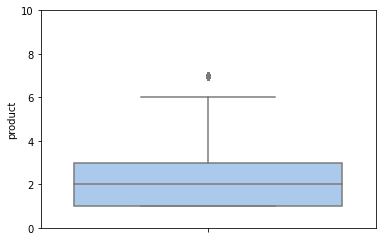

```python
# график боксплот по общему числу продуктов p&g
sns.set_palette('pastel')
sns.boxplot(y=check["product"])
plt.ylim(0, 10)
```

```
(0.0, 16.0)
```

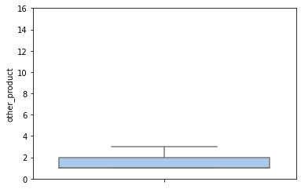

```python
#график боксплот по общему числу продуктов не - p&g в чеках
sns.boxplot(y=check["other_product"])
plt.ylim(0, 16)
```

```python
check['product'].quantile([0.01, 0.25, 0.5, 0.75, 0.95, 0.99])
```

```
0.01    1.0
0.25    1.0
0.50    2.0
0.75    3.0
0.95    6.0
0.99    7.0
Name: product, dtype: float64
```

Меньше 5% товаров в чеках содержат больше 8 товаров P&G. Удалим эти выбросы.

```python
check['other_product'].quantile([0.01, 0.25, 0.5, 0.75, 0.95, 0.99])
```

```
0.01    1.0
0.25    1.0
0.50    1.0
0.75    2.0
0.95    2.0
0.99    3.0
Name: other_product, dtype: float64
```

```python
# избавимся от выбросов
check = check[check['other_product'] < 4]
check = check[check['product'] < 8]
```

```python
# создадим общее количество товаров в столбце total
check['total'] = check['product'] + check['other_product']
```

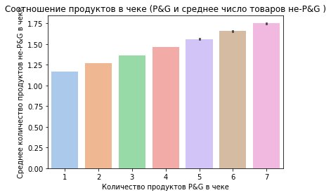

```python
fig = sns.barplot(x = 'product', y = 'other_product', data = check, estimator=np.mean)
plt.xlabel("Количество продуктов P&G в чеке")
plt.ylabel("Среднее количество продуктов не-P&G в чеке")
plt.title("Соотношение продуктов в чеке (P&G и среднее число товаров не-P&G )")
plt.show(fig)
```

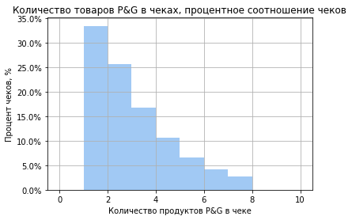

```python
plt.hist(check['product'], weights=np.ones(len(check['product'])) / len(check['product']), range = (0, 20),bins=[0, 1, 2, 3, 4, 5, 6,7,8,9,10])
plt.grid()
plt.gca().yaxis.set_major_formatter(PercentFormatter(1))
plt.title('Количество товаров P&G в чеках, процентное соотношение чеков')
plt.xlabel("Количество продуктов P&G в чеке")
plt.ylabel("Процент чеков, %")
plt.show()
```

Создадим таблицу, в которой представлены не данные по покупкам, а чеки c полной информацией о купленных товарах и информацией о покупателях.

```python
checks = check.merge(right = customers, on='customer', how='left')
#checks
```

```python
checks
```

|  | purchase date | customer | product | other_product | p&g_product | total | customer_age_group | gender | enr_channel | enr_date |
| --- | --- | --- | --- | --- | --- | --- | --- | --- | --- | --- |
| 0 | 2021-01-01 | 0008953dbc5953295be0 | 1 | 1 | 0 | 2 | [26 - 30] | F | SMS | 2020-09-12 |
| 1 | 2021-01-01 | 00187df32ea47dc11b19 | 4 | 2 | 0 | 6 | [41 - 45] | F | SMS | 2019-11-09 |
| 2 | 2021-01-01 | 0046501ed1ef6caca36e | 2 | 1 | 0 | 3 | [31 - 35] | M | Mobile App | 2019-10-25 |
| 3 | 2021-01-01 | 006c1fd27cd3eec956d6 | 2 | 1 | 0 | 3 | [46 - 50] | U | Mobile App | 2020-03-14 |
| 4 | 2021-01-01 | 00a4706b922f66bc2d0b | 2 | 1 | 0 | 3 | [31 - 35] | M | Mobile App | 2019-11-03 |
| ... | ... | ... | ... | ... | ... | ... | ... | ... | ... | ... |
| 4041987 | 2021-12-31 | fff4c6f39c08a9cb5b55 | 2 | 2 | 0 | 4 | [36 - 40] | F | Mobile App | 2019-10-28 |
| 4041988 | 2021-12-31 | fff5a4b98e96b4363e5e | 1 | 1 | 0 | 2 | [26 - 30] | M | Batch File | 2020-10-10 |
| 4041989 | 2021-12-31 | fff652b6e52c0778c2de | 2 | 2 | 1 | 4 | [51 and more] | F | SMS | 2019-11-05 |
| 4041990 | 2021-12-31 | fff99802e958caf47ceb | 7 | 1 | 0 | 8 | [36 - 40] | F | Customer Web Portal | 2019-10-31 |
| 4041991 | 2021-12-31 | fffe956d3fce9c2251dd | 4 | 2 | 0 | 6 | [36 - 40] | F | Back Office | 2020-04-11 |

4041992 rows × 10 columns

```python
# посчитаем число уникальных покупателей продукции P&G по их половозрастному составу. для этого вычленим из нашей таблицы с чекми только уникальных покупателей
checksun = pd.DataFrame(check['customer'].unique())
checksun.columns = ['customer']
checksun = checksun.merge(right = customers, on='customer', how='left')
```

| gender customer_age_group | F | M | U | total |
| --- | --- | --- | --- | --- |
| [51 and more] | 57579 | 14997 | 4623 | 77199 |
| [46 - 50] | 19918 | 6740 | 2238 | 28896 |
| [41 - 45] | 26144 | 9609 | 3257 | 39010 |
| [36 - 40] | 32526 | 12870 | 4394 | 49790 |
| [31 - 35] | 32748 | 16142 | 5010 | 53900 |
| [26 - 30] | 22162 | 15858 | 4733 | 42753 |
| [21 - 25] | 17981 | 17871 | 4943 | 40795 |
| [18 - 20] | 5284 | 1648 | 1574 | 8506 |

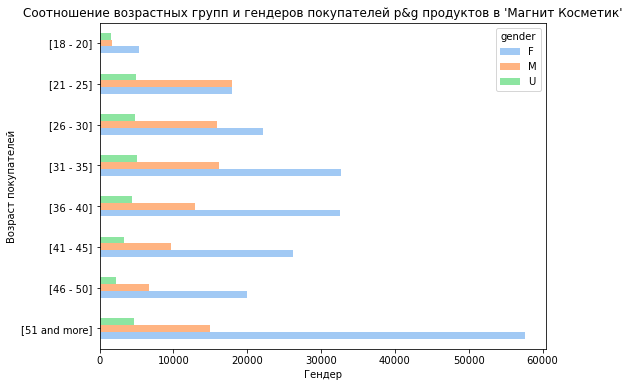

```python
report = checksun.pivot_table(index = 'customer_age_group', columns = 'gender', values = 'customer', aggfunc = 'nunique')
report['total'] = report['F'] + report['M']+ report['U']
report = report.sort_values('customer_age_group', ascending = False)
display(report)
report[['F', 'M', 'U']].plot(kind = 'barh', figsize = (8, 6))
plt.ylabel("Возраст покупателей")
plt.xlabel("Гендер")
plt.title ("Соотношение возрастных групп и гендеров покупателей p&g продуктов в 'Магнит Косметик'")
```

Отражает ли этот график половозростные особенности покупателей P&G продукции, либо это распределение стандартно для покупателей "Магнит Косметик" в целом? Для того, чтобы это узнать, сравним этот график покупателей P&G с общими покупателями, зарегистрированными в "Магнит Косметик".

| gender customer_age_group | F | M | U | total |
| --- | --- | --- | --- | --- |
| [51 and more] | 58935 | 15782 | 4782 | 79499 |
| [46 - 50] | 20424 | 7070 | 2319 | 29813 |
| [41 - 45] | 26788 | 10052 | 3377 | 40217 |
| [36 - 40] | 33274 | 13490 | 4533 | 51297 |
| [31 - 35] | 33367 | 17040 | 5167 | 55574 |
| [26 - 30] | 22681 | 16699 | 4915 | 44295 |
| [21 - 25] | 18449 | 18806 | 5143 | 42398 |
| [18 - 20] | 5420 | 1784 | 1654 | 8858 |

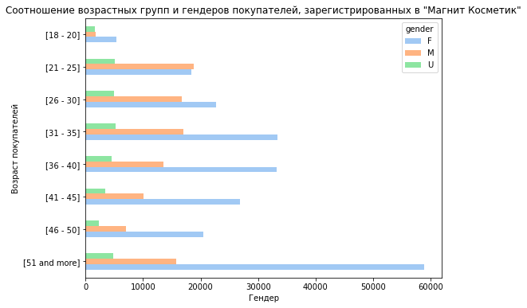

```python
# половозрастное распределение покупателей системы "Магнит Косметик"
report = customers.pivot_table(index = 'customer_age_group', columns = 'gender', values = 'customer', aggfunc = 'nunique')
report['total'] = report['F'] + report['M']+ report['U']
report = report.sort_values('customer_age_group', ascending = False)
display(report)
report[['F', 'M', 'U']].plot(kind = 'barh', figsize = (8, 6))
plt.ylabel("Возраст покупателей")
plt.xlabel("Гендер")
plt.title ('Соотношение возрастных групп и гендеров покупателей, зарегистрированных в "Магнит Косметик"')
```

Графики практически идентичны. Это означает, что половозрастной состав покупателей, у которых в чеке есть хотя бы один товар P&G, не отличаются от общего половозрастного состава покупателей магазина "Магнит-косметик". Мы также можем отметить, что абсолютное численное выражаение покупающих P&G не сильно отличается от общего числа зарегистрированных в магните. Это значит, что подавляющее число зарегистрированных в системе "Магнит Косметик" покупают или покупали продукцию P&G.